# Chapter 6 Code

Xi Liang

5/25/2017

## Example 1. Predicting medical expense using linear regression

### 1a. Exploring and preparing the data

```r
insurance <- read.csv("data/insurance.csv")
```

```r
str(insurance)
```

```
## 'data.frame':    1338 obs. of  7 variables:
##  $ age     : int  19 18 28 33 32 31 46 37 37 60 ...
##  $ sex     : Factor w/ 2 levels "female","male": 1 2 2 2 2 1 1 1 2 1 ...
##  $ bmi     : num  27.9 33.8 33 22.7 28.9 ...
##  $ children: int  0 1 3 0 0 0 1 3 2 0 ...
##  $ smoker  : Factor w/ 2 levels "no","yes": 2 1 1 1 1 1 1 1 1 1 ...
##  $ region  : Factor w/ 4 levels "northeast","northwest",..: 4 3 3 2 2 3 3 2 1 2 ...
##  $ charges : num  16885 1726 4449 21984 3867 ...
```

This data includes 1,338 examples of beneficiares currently enrolled in the insurance plan, with features indicating characteristics of the patient as well as the total medical expenses charged to the plan for the calendar year. The features are:

- age: An integer indicating the age of the primary beneficiary (excluding those above 64 years, since they are genearlly covered by the government).
- sex: The policy holder’s gender, either male or female.
- bmi: The body mass index (BMI), which provides a sense of how over-or under-weight a pwerson is relative to their weight. An ideal BMI is within the range of 18.5 to 24.9.
- children: An integer indicating the number of children/dependents covered by the insurance plan.
- smoker: A yes or no categorical variable that indicates whether the insured regularly smokes tobacco.
- region: The beneficiary’s place of residence in the US, divided in the four regions: northeast, southeast, southwest, or northwest.

### 1b. Exploring and preparing the data

Before the next step, we would like to check the normality of our response variable.

```r
summary(insurance$charges)
```

```
##    Min. 1st Qu.  Median    Mean 3rd Qu.    Max.
##    1122    4740    9382   13270   16640   63770
```

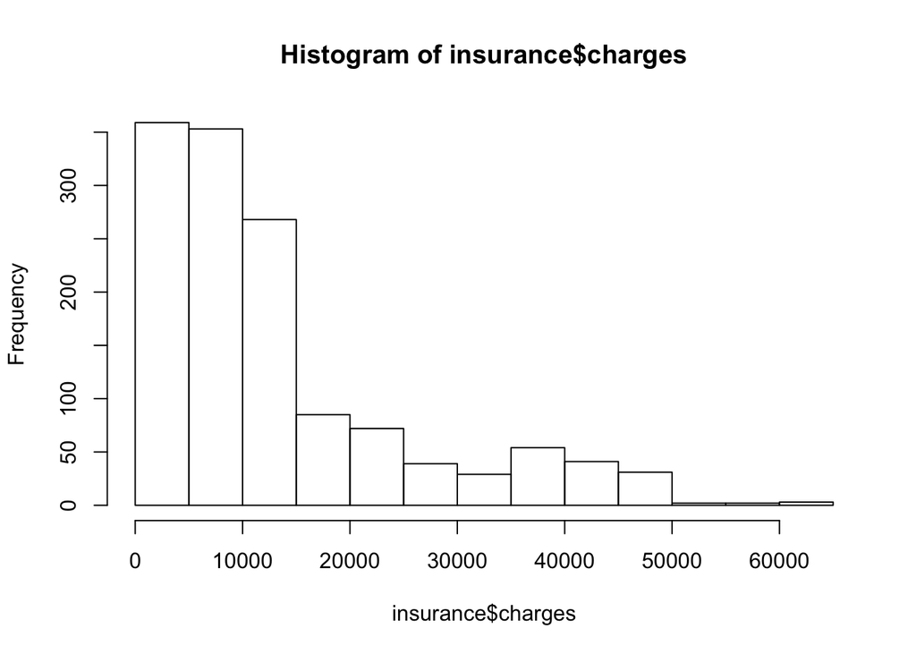

```r
hist(insurance$charges)
```

The distribution of the response varibale is right-skewed. It also shows that the majority of people in our data have yearly medical expenses between zero and $15,000.

### 1c. Exploring relationshps among features - the correlation matrix

```r
library(corrplot)
library(dplyr)
cor(insurance[c("age", "bmi", "children", "charges")])
```

```
##                age       bmi   children    charges
## age      1.0000000 0.1092719 0.04246900 0.29900819
## bmi      0.1092719 1.0000000 0.01275890 0.19834097
## children 0.0424690 0.0127589 1.00000000 0.06799823
## charges  0.2990082 0.1983410 0.06799823 1.00000000
```

### 1d. Visualizing relationships among features - the scatterplot matrix

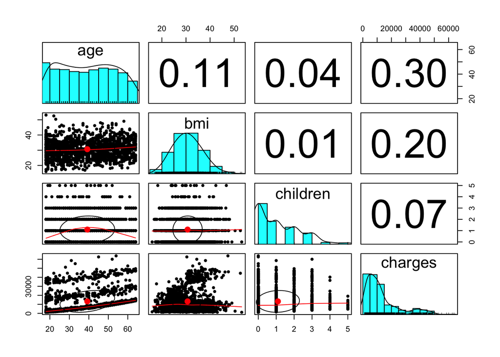

```r
library(psych)
pairs.panels(insurance[c("age", "bmi", "children", "charges")])
```

We also obseved that the in scatter plot between BMI and age, the losess curve is a line sloping gradually up, which implies that body mass increases with age. In addition, in the scatter plot of age and children, we observed that middle age individuals have more children that younger and older people.

Bear in mind that the above correlation plot only included numerical variables, we would see how categorical variables behave in the model.

### 1e. Training a model on the data

```r
ins_model <- lm(charges ~., data = insurance)

ins_model
```

```
##
## Call:
## lm(formula = charges ~ ., data = insurance)
##
## Coefficients:
##     (Intercept)              age          sexmale              bmi
##        -11938.5            256.9           -131.3            339.2
##        children        smokeryes  regionnorthwest  regionsoutheast
##           475.5          23848.5           -353.0          -1035.0
## regionsouthwest
##          -960.1
```

Through the intepretation of the beta coefficients, we’ve gain the following insight: old age, smoking, and obsesity tend to be linked to addtional health issues, while addtional family member dependents may result an increase in physician visits and preventive care.

### 1f. evaluating model performance

```r
summary(ins_model)
```

```
##
## Call:
## lm(formula = charges ~ ., data = insurance)
##
## Residuals:
##      Min       1Q   Median       3Q      Max
## -11304.9  -2848.1   -982.1   1393.9  29992.8
##
## Coefficients:
##                 Estimate Std. Error t value Pr(>|t|)
## (Intercept)     -11938.5      987.8 -12.086  < 2e-16 ***
## age                256.9       11.9  21.587  < 2e-16 ***
## sexmale           -131.3      332.9  -0.394 0.693348
## bmi                339.2       28.6  11.860  < 2e-16 ***
## children           475.5      137.8   3.451 0.000577 ***
## smokeryes        23848.5      413.1  57.723  < 2e-16 ***
## regionnorthwest   -353.0      476.3  -0.741 0.458769
## regionsoutheast  -1035.0      478.7  -2.162 0.030782 *
## regionsouthwest   -960.0      477.9  -2.009 0.044765 *
## ---
## Signif. codes:  0 '***' 0.001 '**' 0.01 '*' 0.05 '.' 0.1 ' ' 1
##
## Residual standard error: 6062 on 1329 degrees of freedom
## Multiple R-squared:  0.7509, Adjusted R-squared:  0.7494
## F-statistic: 500.8 on 8 and 1329 DF,  p-value: < 2.2e-16
```

Based on the p-values, the model finds variables age, BMI, children, and smoking statistically significant.

Multiple R-sqaured tells us that the model explains nearly 75% of the variation in the dependent variable.

### 1g. improving model performance

1. adding no-linear relationships The relationship between age and expense might not be linear; the treatment may become disproportionately expensive for oldest populations, hence we will add a higher order term to the variable “age”.

```r
insurance$age2 <- insurance$age^2
```

2. transformation - converting a numeric variable to a binary indicator We speculate that the effect of variable “bmi” is not cumulative, rather it has an effect only after a specific threshold has been reached, for example, BMI might have zero impact on medical expenditures for individuals in the normal weight range, but it may be strongly related to higher costs for the obese ( > 30).

```r
insurance$bmi30 <- ifelse(insurance$bmi >= 30, 1, 0)
```

3. model specification - adding interaction effects While considering bmi and smoking contribution to the outcome individually, we should also consider that the combined effect of these variables may be worse than the sum of each one alone. As the result, in the later modeling process, we should include “bmi30*smoker“.

### 1h. putting it all together - an improved regression model

```r
ins_model2 <- lm(charges ~ age + age2 + children + bmi + sex + bmi30*smoker + region, data = insurance)
```

```r
summary(ins_model2)
```

```
##
## Call:
## lm(formula = charges ~ age + age2 + children + bmi + sex + bmi30 *
##     smoker + region, data = insurance)
##
## Residuals:
##      Min       1Q   Median       3Q      Max
## -17296.4  -1656.0  -1263.3   -722.1  24160.2
##
## Coefficients:
##                   Estimate Std. Error t value Pr(>|t|)
## (Intercept)       134.2509  1362.7511   0.099 0.921539
## age               -32.6851    59.8242  -0.546 0.584915
## age2                3.7316     0.7463   5.000 6.50e-07 ***
## children          678.5612   105.8831   6.409 2.04e-10 ***
## bmi               120.0196    34.2660   3.503 0.000476 ***
## sexmale          -496.8245   244.3659  -2.033 0.042240 *
## bmi30           -1000.1403   422.8402  -2.365 0.018159 *
## smokeryes       13404.6866   439.9491  30.469  < 2e-16 ***
## regionnorthwest  -279.2038   349.2746  -0.799 0.424212
## regionsoutheast  -828.5467   351.6352  -2.356 0.018604 *
## regionsouthwest -1222.6437   350.5285  -3.488 0.000503 ***
## bmi30:smokeryes 19810.7533   604.6567  32.764  < 2e-16 ***
## ---
## Signif. codes:  0 '***' 0.001 '**' 0.01 '*' 0.05 '.' 0.1 ' ' 1
##
## Residual standard error: 4445 on 1326 degrees of freedom
## Multiple R-squared:  0.8664, Adjusted R-squared:  0.8653
## F-statistic: 781.7 on 11 and 1326 DF,  p-value: < 2.2e-16
```

By comparing the ajusted R-squared, we can conclude that the second model is better than the previous one.

## Example 2. Estimating the quality of wines with regression trees and model trees

### 2a. exploring and preparing the data

```r
wine <- read.csv("data/whitewines.csv")
```

```r
str(wine)
```

```
## 'data.frame':    4898 obs. of  12 variables:
##  $ fixed.acidity       : num  7 6.3 8.1 7.2 7.2 8.1 6.2 7 6.3 8.1 ...
##  $ volatile.acidity    : num  0.27 0.3 0.28 0.23 0.23 0.28 0.32 0.27 0.3 0.22 ...
##  $ citric.acid         : num  0.36 0.34 0.4 0.32 0.32 0.4 0.16 0.36 0.34 0.43 ...
##  $ residual.sugar      : num  20.7 1.6 6.9 8.5 8.5 6.9 7 20.7 1.6 1.5 ...
##  $ chlorides           : num  0.045 0.049 0.05 0.058 0.058 0.05 0.045 0.045 0.049 0.044 ...
##  $ free.sulfur.dioxide : num  45 14 30 47 47 30 30 45 14 28 ...
##  $ total.sulfur.dioxide: num  170 132 97 186 186 97 136 170 132 129 ...
##  $ density             : num  1.001 0.994 0.995 0.996 0.996 ...
##  $ pH                  : num  3 3.3 3.26 3.19 3.19 3.26 3.18 3 3.3 3.22 ...
##  $ sulphates           : num  0.45 0.49 0.44 0.4 0.4 0.44 0.47 0.45 0.49 0.45 ...
##  $ alcohol             : num  8.8 9.5 10.1 9.9 9.9 10.1 9.6 8.8 9.5 11 ...
##  $ quality             : int  6 6 6 6 6 6 6 6 6 6 ...
```

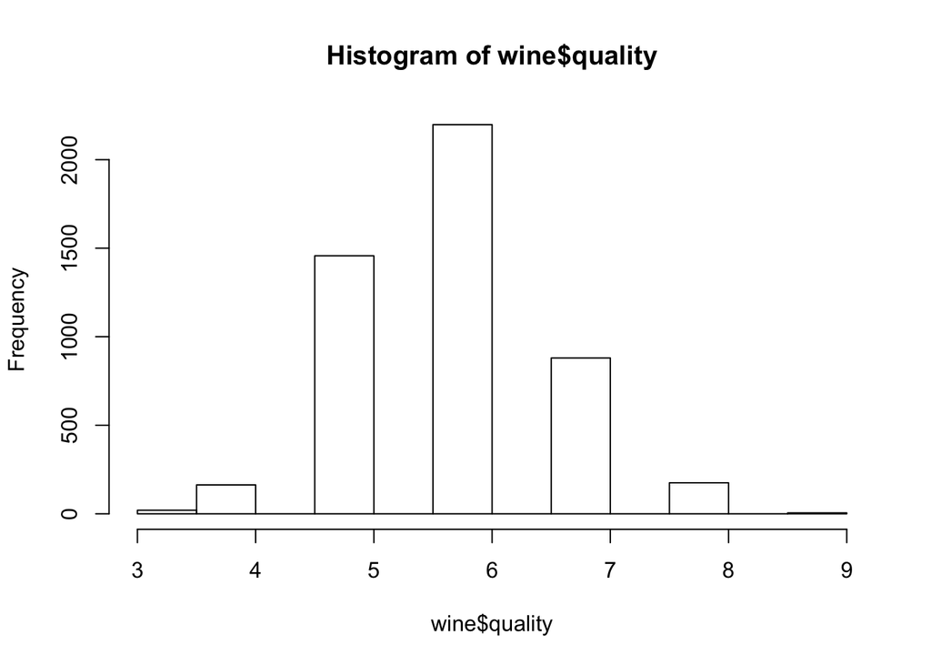

```r
hist(wine$quality)
```

```r
wine_train <- wine[1:3750, ]
wine_test <- wine[3751:4898, ]
```

### 2b. training a model on the data

```r
library(rpart)

m.rpart <- rpart(quality ~., data = wine_train)
```

```r
m.rpart
```

```
## n= 3750
##
## node), split, n, deviance, yval
##       * denotes terminal node
##
##  1) root 3750 3140.06000 5.886933
##    2) alcohol< 10.85 2473 1510.66200 5.609381
##      4) volatile.acidity>=0.2425 1406  740.15080 5.402560
##        8) volatile.acidity>=0.4225 182   92.99451 4.994505 *
##        9) volatile.acidity< 0.4225 1224  612.34560 5.463235 *
##      5) volatile.acidity< 0.2425 1067  631.12090 5.881912 *
##    3) alcohol>=10.85 1277 1069.95800 6.424432
##      6) free.sulfur.dioxide< 11.5 93   99.18280 5.473118 *
##      7) free.sulfur.dioxide>=11.5 1184  879.99920 6.499155
##       14) alcohol< 11.85 611  447.38130 6.296236 *
##       15) alcohol>=11.85 573  380.63180 6.715532 *
```

```r
summary(m.rpart)
```

```
## Call:
## rpart(formula = quality ~ ., data = wine_train)
##   n= 3750
##
##           CP nsplit rel error    xerror       xstd
## 1 0.17816211      0 1.0000000 1.0010057 0.02388229
## 2 0.04439109      1 0.8218379 0.8272964 0.02240648
## 3 0.02890893      2 0.7774468 0.7879213 0.02207043
## 4 0.01655575      3 0.7485379 0.7585109 0.02080308
## 5 0.01108600      4 0.7319821 0.7445996 0.02046949
## 6 0.01000000      5 0.7208961 0.7424987 0.02037738
##
## Variable importance
##              alcohol              density            chlorides
##                   38                   23                   12
##     volatile.acidity total.sulfur.dioxide  free.sulfur.dioxide
##                   12                    7                    6
##            sulphates                   pH       residual.sugar
##                    1                    1                    1
##
## Node number 1: 3750 observations,    complexity param=0.1781621
##   mean=5.886933, MSE=0.8373493
##   left son=2 (2473 obs) right son=3 (1277 obs)
##   Primary splits:
##       alcohol              < 10.85    to the left,  improve=0.17816210, (0 missing)
##       density              < 0.992385 to the right, improve=0.11980970, (0 missing)
##       chlorides            < 0.0395   to the right, improve=0.08199995, (0 missing)
##       total.sulfur.dioxide < 153.5    to the right, improve=0.03875440, (0 missing)
##       free.sulfur.dioxide  < 11.75    to the left,  improve=0.03632119, (0 missing)
##   Surrogate splits:
##       density              < 0.99201  to the right, agree=0.869, adj=0.614, (0 split)
##       chlorides            < 0.0375   to the right, agree=0.773, adj=0.334, (0 split)
##       total.sulfur.dioxide < 102.5    to the right, agree=0.705, adj=0.132, (0 split)
##       sulphates            < 0.345    to the right, agree=0.670, adj=0.031, (0 split)
##       fixed.acidity        < 5.25     to the right, agree=0.662, adj=0.009, (0 split)
##
## Node number 2: 2473 observations,    complexity param=0.04439109
##   mean=5.609381, MSE=0.6108623
##   left son=4 (1406 obs) right son=5 (1067 obs)
##   Primary splits:
```

[output cut: 57 more lines]

```
##       chlorides            < 0.0365   to the right, agree=0.631, adj=0.237, (0 split)
##       total.sulfur.dioxide < 126.5    to the right, agree=0.566, adj=0.103, (0 split)
##       residual.sugar       < 1.525    to the left,  agree=0.560, adj=0.091, (0 split)
##
## Node number 8: 182 observations
##   mean=4.994505, MSE=0.5109588
##
## Node number 9: 1224 observations
##   mean=5.463235, MSE=0.5002823
##
## Node number 14: 611 observations
##   mean=6.296236, MSE=0.7322117
##
## Node number 15: 573 observations
##   mean=6.715532, MSE=0.6642788
```

### 2c. visualizing decision trees

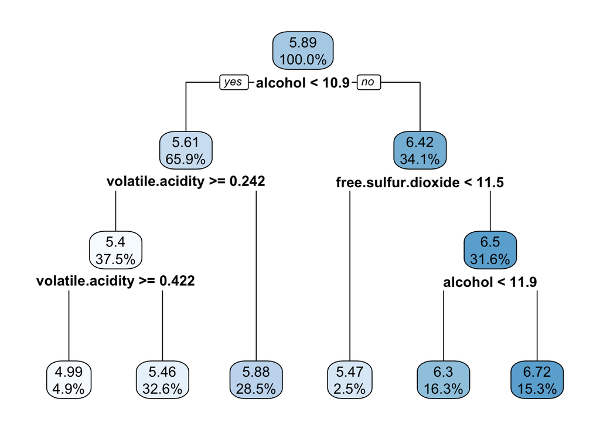

```r
library(rpart.plot)
rpart.plot(m.rpart, digits = 3)
```

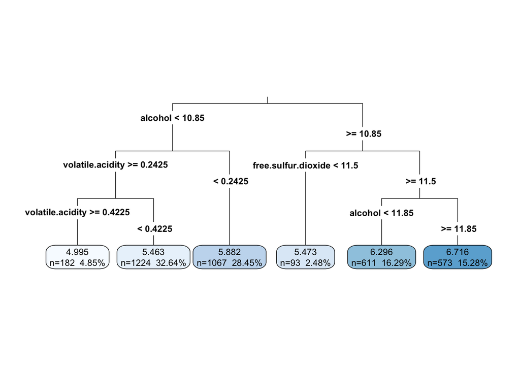

```r
rpart.plot(m.rpart, digits = 4, fallen.leaves = TRUE,
           type = 3, extra = 101)
```

### 2d. evaluating model performance

```r
p.rpart <- predict(m.rpart, wine_test)
```

```r
summary(p.rpart)
```

```
##    Min. 1st Qu.  Median    Mean 3rd Qu.    Max.
##   4.995   5.463   5.882   5.999   6.296   6.716
```

```r
summary(wine_test$quality)
```

```
##    Min. 1st Qu.  Median    Mean 3rd Qu.    Max.
##   3.000   5.000   6.000   5.848   6.000   8.000
```

Comparing the distribution of our predicted values and the expected values, we notice that the model is not correctly identifying the extreme cases, in particular the best and the worst wines.

To evaluate the model performance, we could use the correlation between the predicted and actualy values in order to measure the relationship.

```r
cor(p.rpart, wine_test$quality)
```

```
## [1] 0.4931608
```

While correlation measures how strongly the predictions are related to true value, it is not measuring how far off the predictions were from the true values. To evaluate our model performance based on how far, we will use mean absolute error.

```r
#function to calculate the mean absolute error
MAE <- function(actual, predicted) {
  mean(abs(actual - predicted))
}
```

```r
MAE(p.rpart, wine_test$quality)
```

```
## [1] 0.5732104
```

The MAE value is 0.57, which implies that on avareage, the difference between our model’s predictions and the true quality score was 0.57.

```r
mean(wine_train$quality)
```

```
## [1] 5.886933
```

```r
MAE(5.89, wine_test$quality)
```

```
## [1] 0.5741115
```

From the MAE score of the mean of the quality score and actual quality score, one can notice that the model is predicting values close to the mean value. There might be room for improvment.

### 2e. improving model performance

```r
library(randomForest)
m.randomForest <- randomForest(quality ~., data = wine_train)
```

```r
m.randomForest
```

```
##
## Call:
##  randomForest(formula = quality ~ ., data = wine_train)
##                Type of random forest: regression
##                      Number of trees: 500
## No. of variables tried at each split: 3
##
##           Mean of squared residuals: 0.3684946
##                     % Var explained: 55.99
```

```r
pred.randomForest <- predict(m.randomForest, wine_test)
summary(pred.randomForest)
```

```
##    Min. 1st Qu.  Median    Mean 3rd Qu.    Max.
##   4.587   5.578   6.021   6.016   6.436   7.363
```

```r
cor(pred.randomForest, wine_test$quality)
```

```
## [1] 0.6085838
```

```r
MAE(pred.randomForest, wine_test$quality)
```

```
## [1] 0.5189814
```

#### further tunning via grid search

```r
library(e1071)
```

```r
tuned.rF <- tune(randomForest, train.x = quality ~.,
                 data = wine_train,
                 validation.x = wine_test)

best.rF <- tuned.rF$best.model
```

```r
best.rF.pred <- predict(best.rF, wine_test)
summary(best.rF.pred)
```

```
##    Min. 1st Qu.  Median    Mean 3rd Qu.    Max.
##   4.536   5.558   6.009   6.016   6.437   7.395
```

```r
cor(best.rF.pred, wine_test$quality)
```

```
## [1] 0.6133175
```

```r
MAE(best.rF.pred, wine_test$quality)
```

```
## [1] 0.5171156
```